# DO-MS Report

Version: 2.0.b5 | PEP < -Inf | Generated: 2022-05-18 18:22:32

## Summary

### DIA-NN Experiments

DIA-NN Experiments

wGW032 F:/GW/raw_data/wGW032.raw

wGW033 F:/GW/raw_data/wGW033.raw

wGW034 F:/GW/raw_data/wGW034.raw

wGW035 F:/GW/raw_data/wGW035.raw

wGW036 F:/GW/raw_data/wGW036.raw

wGW037 F:/GW/raw_data/wGW037.raw

wGW038 F:/GW/raw_data/wGW038.raw

## Ion Sampling

### Channel wise MS1 Intensity for Precursors

Plotting the MS1 intensity for all precursors which were associated with one of the defined channels.

[output not shown]

### Precursors Identified across Gradient

Precursor are plotted across the chromatographic gradient.

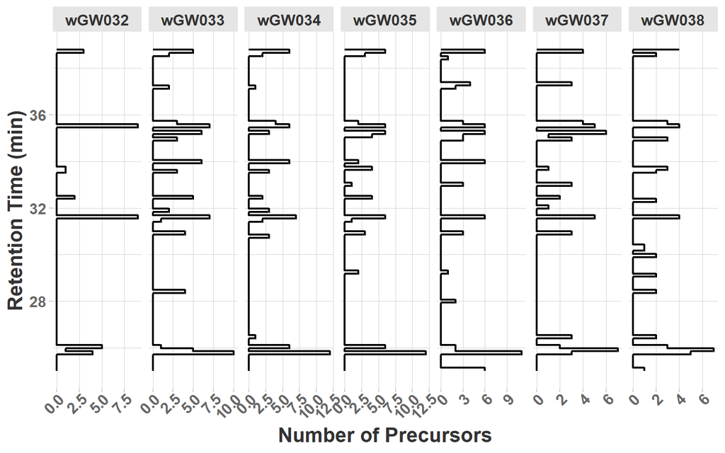

### MS1 Intensity summed over all Channels.

Plotting the MS1 intensity for all precursors summed over all channels.

[output not shown]

### MS1 Intensity for Intersected Precursors, summed over all Channels.

Plotting the MS1 intensity for all precursors summed over all channels. Only intersected precursors present in all loaded experiments are shown.

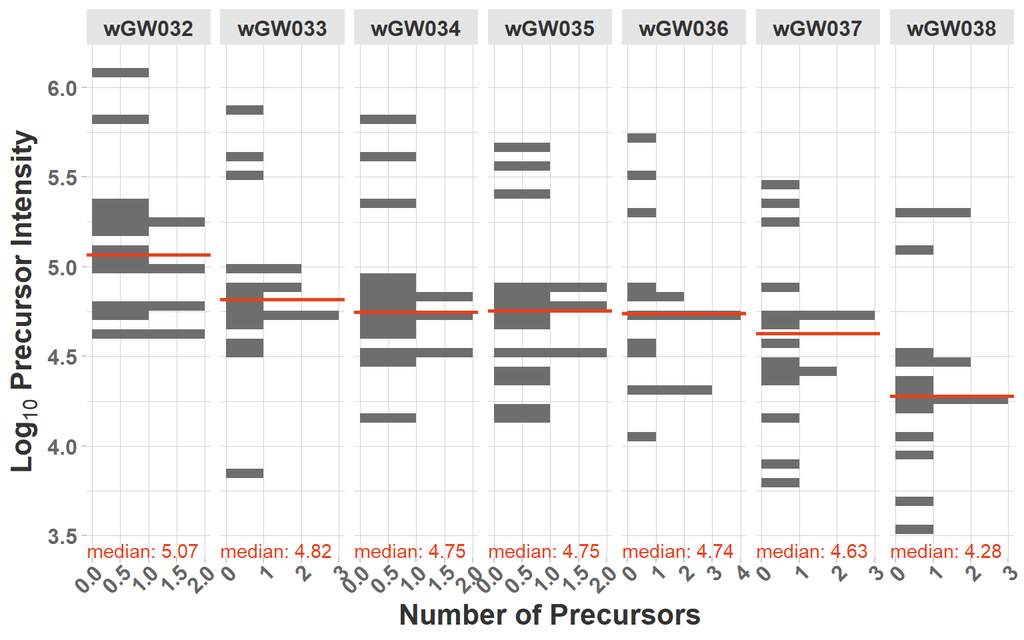

### Normalized MS1 Intensity for Intersected Precursors

Plotting the MS1 Intensity for intersected precursors summed over all channels. Experiments are normalized to the first experiment.

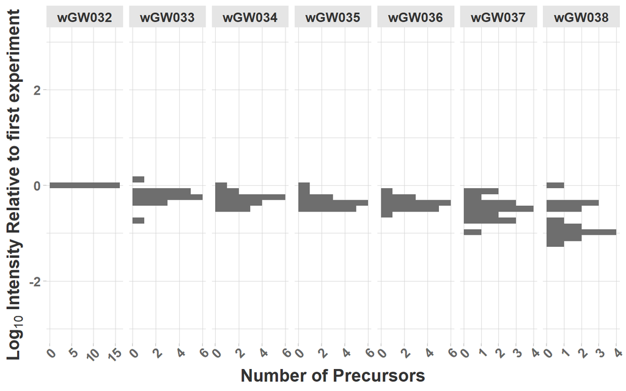

### Number of Precursors by Charge State

Number of precursors observed during MS1 scans by charge state

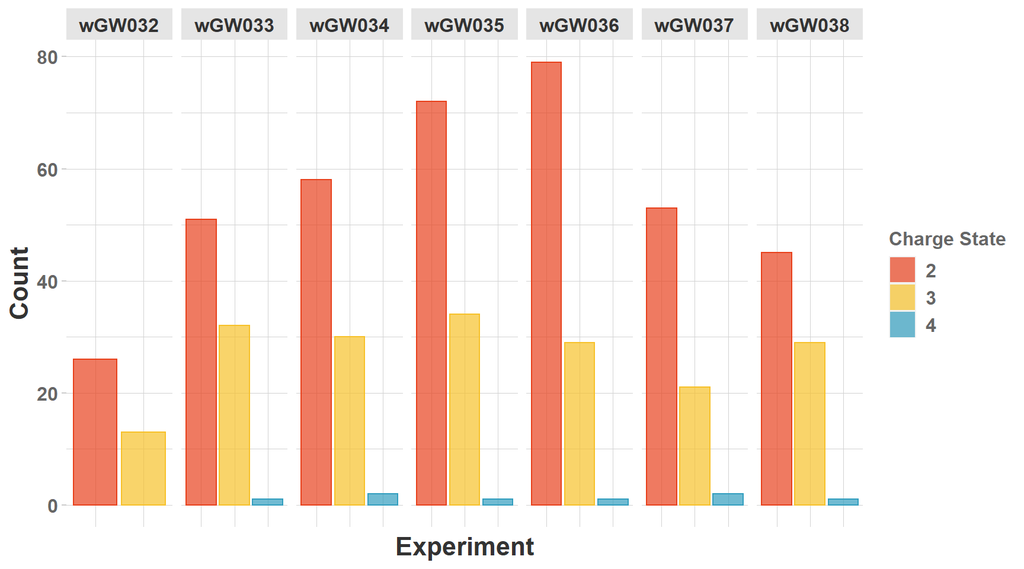

### Ms1 Fill Time Distribution

Ms1 fill times along gradient

[output not shown]

### Ms1 Fill Times along Gradient

The averge fill time is shown in magenta for different bins along the retention time gradient. The standard deviation is depicted as area in blue, scans outside this area are shown as single datapoints.

[output not shown]

### Ms1 total Ion Current along Gradient

The toal Ion Current (TIC) is shown for bins along the retention time gradient.

[output not shown]

### Ms2 Fill Time Distribution

Ms2 fill times along gradient

[output not shown]

### Ms2 Fill Times along Gradient

The averge fill time is shown in magenta for different bins along the retention time gradient. The standard deviation is depicted as area in blue, scans outside this area are shown as single datapoints.

[output not shown]

### Ms2 Fill Time Matrix

The average Ms2 fill times are shown across the gradient for every distinct Ms2 window.

[output not shown]

### Channel wise MS1 Counts for Precursors

Plotting the MS1 counts based on the signal to noise ratio for all precursors which were associated with one of the defined channels.

[output not shown]

## Identifications

### Number of Confident Precursor Identifications

Plotting the number of precursors identified at each given confidence level.

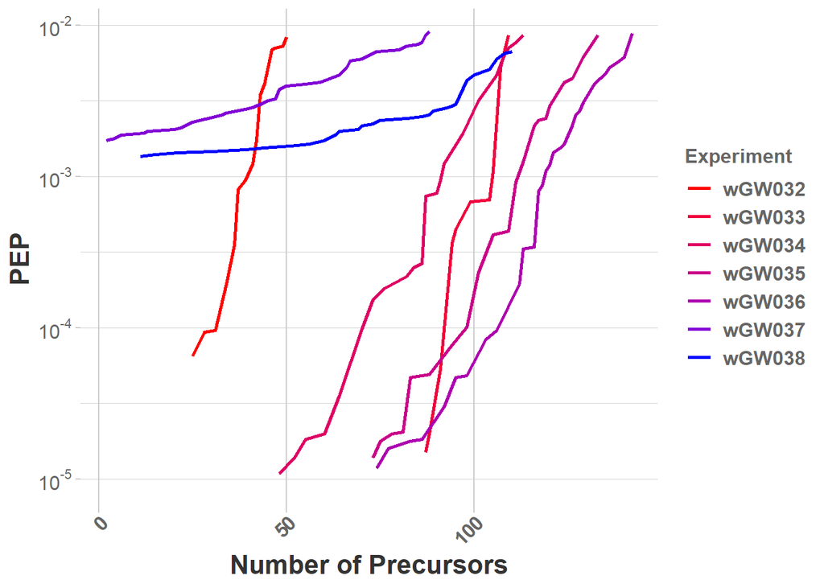

### Precursors by Quantification Strategy

Number of precursors found based on quantification startegy. Ms2 precursors are counted based on Precursor.Quantity > 0 and Ms1 precursors are counted based on Ms1.Area > 0.

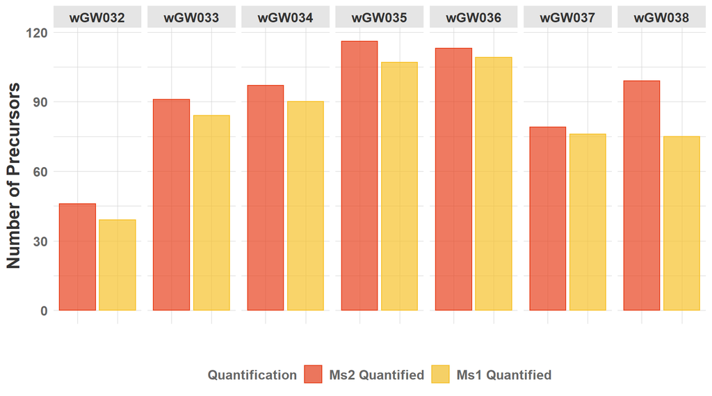

### Precursors by Modification

Number of precursors found based on modification types specified

[output not shown]

### Miscleavage Rate (percentage), PEP < 0.01

Miscleavage rate (percentage) for precursors identified with confidence PEP < 0.01

| Raw.file | None | 1 | % Missed cleavages |
| --- | --- | --- | --- |
| wGW032 | 39 | 0 | 0.000000 |
| wGW033 | 80 | 4 | 4.761905 |
| wGW034 | 85 | 5 | 5.555556 |
| wGW035 | 103 | 4 | 3.738318 |
| wGW036 | 105 | 4 | 3.669725 |
| wGW037 | 71 | 5 | 6.578947 |
| wGW038 | 69 | 6 | 8.000000 |

### Miscleavage Rate (K), PEP < 0.01

Plotting frequency of lysine miscleavages in confidently identified precursors.

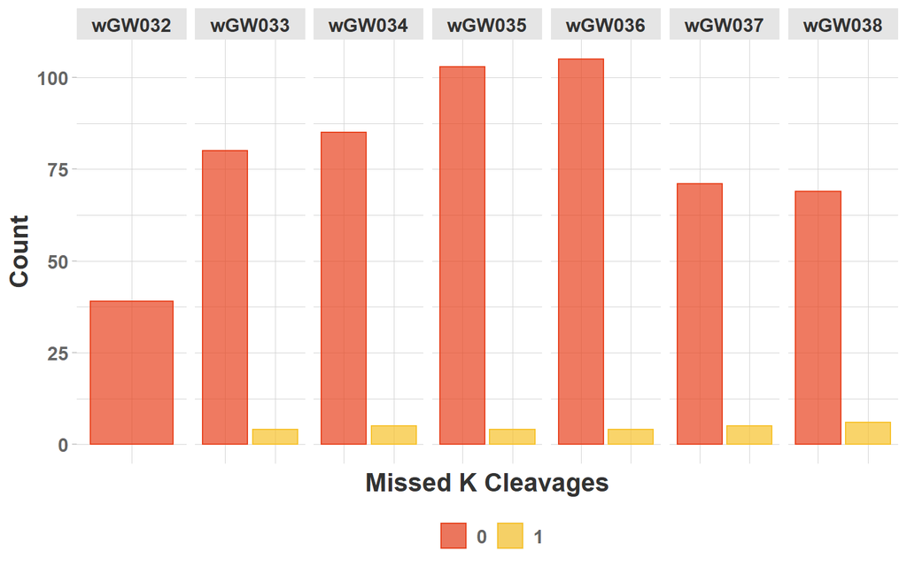

### Miscleavage Rate (R), PEP < 0.01

Plotting frequency of arginine miscleavages in confidently identified precursors.

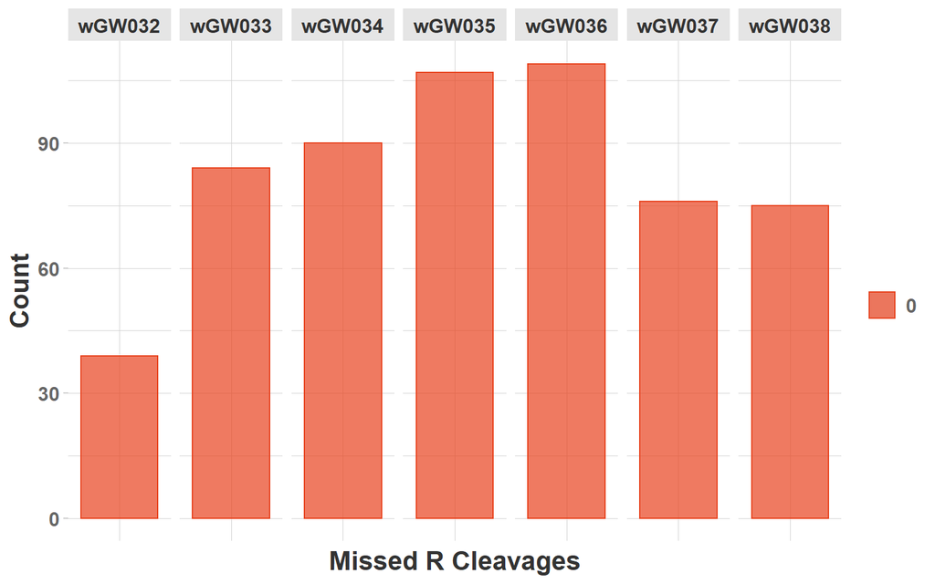

### Number of Protein Identifications

Number of proteotypic protein IDs found per run. Protein IDs are shown across all channels in an experiment.

[output not shown]

## plex-DIA Diagnostics

### Identified Precursors per Channel

The number of precursors identified is shown for every channel together with the number of total and intersected precursors. The number of precursors is based on all precursors found in the report.tsv file which is by default controlled by a run-specific FDR.

[output not shown]

### Identified Precursors per Channel, Channel Q-Value

The number of precursors identified is shown for every channel together with the number of total and intersected precursors. The number of precursors is based on all precursors with a Channel.Q.Value <= 0.01.

[output not shown]

### Identified Proteins per Channel

The number of Proteins identified is shown for every channel together with the number of total and intersected proteins. The number of proteins is based on all proteotypic precursors independent of the Protein.Q.Value.

[output not shown]

### Relative Single-Cell Intensity

Single-Cell intensity relative to the carrier channel for intersected precursors

[output not shown]

### Total MS1 Precursors

Total number of precursors identified based on different confidence metrics.

[output not shown]

### Missing Data, Precursor Level

Plotting the Jaccard Index for identified precursors for all channel combinations.

[output not shown]

### Missing Data, Protein Level

Plotting the Jaccard Index for identified precursors for all channel combinations.

[output not shown]

## Feature Detection

### Features Identified by Charge

Identified features are reported based on the charge. Precursors quantified in seperate channels are treated as separate precursors..

[output not shown]

### Isotopes Identified per Feature

The number of isotopes identified is shown for features detected in the Dinosaur search.

[output not shown]

### Number of Scans per feature

The number of MS1 scans is shown for all features identified in the Dinosaur search.

[output not shown]

### Retention Length of Features at Base

Plotting the retention length of identified features at the base.

[output not shown]

### Features Identified across Gradient

The frequency of precursor identifications based on the Dinosaur search is plotted across the chromatographic gradient.

[output not shown]

### Features Identified across m/z

The frequency of precursor identifications based on the Dinosaur search is plotted across the mass to charge ratio.

[output not shown]

### Feature Intensity Distribution

The distribution of integrated intensities is shown for identified features.

[output not shown]